# Open Data Network Business Intelligence Report

Data-Driven Management Analysis

Gerrit Wichern

2025-11-29

## Section 1: Business Problem Definition and Context

### Strategic Problem Identification Using Data

#### Problem Statement

A corrections service provider must decide which county jails represent the strongest opportunity for expanding its facility-support services. Using historical jail population trends from 1997 onward, the company needs to identify counties with consistently rising inmate populations that indicate growing demand for staffing, food services, medical support, and security technologies. The dataset provides long-term, county-level population patterns that allow forecasting and prioritizing high-growth markets.

## Section 2: Data Source Assessment

### Data Source Documentation

This analysis uses the *Jail Population by County (Beginning 1997)* dataset from the New York State Division of Criminal Justice Services (DCJS). The dataset is publicly available via NY Open Data at: https://data.ny.gov/Public-Safety/Jail-Population-By-County-Beginning-1997/nymx-kgkn/about_data, with API access through: https://data.ny.gov/api/v3/views/nymx-kgkn/query.json.  
DCJS collects these data for regulatory reporting, criminal justice planning, and statewide monitoring of jail capacity and inmate populations. The dataset covers annual jail population counts from 1997 to the present, representing all 64 county jails outside New York City and regional totals that include NYC beginning in 2016. Geographic coverage is statewide, with facility-level granularity. Known limitations include differing NYC counting methods for “State Ready” inmates between 2016–2020, making those years not directly comparable to later counts.

### Access Method Implementation

#### CSV Download from NY Open Data

The dataset was accessed by downloading the CSV file directly from the NY Open Data portal.  
From the dataset page, the “Export” option was used to download the full dataset in CSV format.  
The file was then saved locally in the project directory for reproducible loading within R.

The following code imports the downloaded file into R:

```r
# Load jail population dataset via local CSV download
jail_data <- read.csv("data/Jail_Population_By_County.csv")

# Preview the first rows
head(jail_data)
```

```
##   Facility.Name..ORI. Year Census Boarded.Out Boarded.In In.House.Census
## 1  All NYC Facilities 2024  6,358           5          0           6,353
## 2  All NYC Facilities 2023  6,001           5          0           5,997
## 3  All NYC Facilities 2022  5,562          13          0           5,549
## 4  All NYC Facilities 2021  5,467           4          0           5,463
## 5  All NYC Facilities 2020  4,473           2          0           4,471
## 6  All NYC Facilities 2019  7,234           5          0           7,228
##   Sentenced Civil Federal Technical.Parole.Violators State.Readies
## 1       543     6      95                         21            75
## 2       449     7      90                         21           104
## 3       347     2      85                         53           153
## 4       184     1      75                        244           157
## 5       225     4      63                        368            15
## 6       800     8      75                        738            10
##   Other.Unsentenced
## 1             5,613
## 2             5,326
## 3             4,909
## 4             4,803
## 5             3,796
## 6             5,597
```

#### Data Quality Assessment

To evaluate suitability for business decision-making, the following checks were performed:

```r
# Basic structure and size
dim(jail_data)                     # Verify rows > 500 and columns >= 5
```

```
## [1] 1857   12
```

```r
str(jail_data)                     # Inspect variable types
```

```
## 'data.frame':    1857 obs. of  12 variables:
##  $ Facility.Name..ORI.       : chr  "All NYC Facilities" "All NYC Facilities" "All NYC Facilities" "All NYC Facilities" ...
##  $ Year                      : int  2024 2023 2022 2021 2020 2019 2018 2017 2016 2024 ...
##  $ Census                    : chr  "6,358" "6,001" "5,562" "5,467" ...
##  $ Boarded.Out               : int  5 5 13 4 2 5 6 7 14 192 ...
##  $ Boarded.In                : int  0 0 0 0 0 0 0 0 0 174 ...
##  $ In.House.Census           : chr  "6,353" "5,997" "5,549" "5,463" ...
##  $ Sentenced                 : chr  "543" "449" "347" "184" ...
##  $ Civil                     : int  6 7 2 1 4 8 7 9 11 50 ...
##  $ Federal                   : chr  "95" "90" "85" "75" ...
##  $ Technical.Parole.Violators: chr  "21" "21" "53" "244" ...
##  $ State.Readies             : chr  "75" "104" "153" "157" ...
##  $ Other.Unsentenced         : chr  "5,613" "5,326" "4,909" "4,803" ...
```

```r
# Data completeness
colSums(is.na(jail_data))          # Missing values per column
```

```
##        Facility.Name..ORI.                       Year
##                          0                          0
##                     Census                Boarded.Out
##                          0                          0
##                 Boarded.In            In.House.Census
##                          0                          0
##                  Sentenced                      Civil
##                          0                          0
##                    Federal Technical.Parole.Violators
##                          0                          0
##              State.Readies          Other.Unsentenced
##                          0                          0
```

```r
(colSums(is.na(jail_data)) / nrow(jail_data)) * 100  # Missing % per column
```

```
##        Facility.Name..ORI.                       Year
##                          0                          0
##                     Census                Boarded.Out
##                          0                          0
##                 Boarded.In            In.House.Census
##                          0                          0
##                  Sentenced                      Civil
##                          0                          0
##                    Federal Technical.Parole.Violators
##                          0                          0
##              State.Readies          Other.Unsentenced
##                          0                          0
```

```r
# Cardinality check
sapply(jail_data, function(x) length(unique(x)))
```

```
##        Facility.Name..ORI.                       Year
##                         67                         28
##                     Census                Boarded.Out
##                        630                         98
##                 Boarded.In            In.House.Census
##                         93                        632
##                  Sentenced                      Civil
##                        310                         38
##                    Federal Technical.Parole.Violators
##                        163                        139
##              State.Readies          Other.Unsentenced
##                         89                        468
```

Data Quality Summary

The dataset contains well over 500 observations and more than five variables, with multiple numeric fields (e.g., inmate counts) and categorical variables (e.g., county, year). Preliminary completeness checks indicate that missing values fall well within acceptable thresholds, and most columns are over 90% complete, making the dataset usable for trend and segmentation analysis. The data is collected by the New York State Division of Criminal Justice Services, a reliable regulatory agency with standardized reporting requirements. Because it provides long-term, county-level jail population trends, the dataset is suitable for forecasting service demand and guiding market-entry or resource-allocation decisions for corrections-related businesses.

## Section 3: Comprehensive Data Analysis

#### Descriptive Analytics:

```r
#For easier access: rename columns
colnames(jail_data) <- c(
"facility_name", "year", "census", "boarded_out", "boarded_in",
"inhouse_census", "sentenced", "civil", "federal",
"technical_parole_violators", "state_readies", "other_unsentenced"
)
# Load necessary libraries
library(dplyr)
# Check the structure of the data
str(jail_data)
```

```
## 'data.frame':    1857 obs. of  12 variables:
##  $ facility_name             : chr  "All NYC Facilities" "All NYC Facilities" "All NYC Facilities" "All NYC Facilities" ...
##  $ year                      : int  2024 2023 2022 2021 2020 2019 2018 2017 2016 2024 ...
##  $ census                    : chr  "6,358" "6,001" "5,562" "5,467" ...
##  $ boarded_out               : int  5 5 13 4 2 5 6 7 14 192 ...
##  $ boarded_in                : int  0 0 0 0 0 0 0 0 0 174 ...
##  $ inhouse_census            : chr  "6,353" "5,997" "5,549" "5,463" ...
##  $ sentenced                 : chr  "543" "449" "347" "184" ...
##  $ civil                     : int  6 7 2 1 4 8 7 9 11 50 ...
##  $ federal                   : chr  "95" "90" "85" "75" ...
##  $ technical_parole_violators: chr  "21" "21" "53" "244" ...
##  $ state_readies             : chr  "75" "104" "153" "157" ...
##  $ other_unsentenced         : chr  "5,613" "5,326" "4,909" "4,803" ...
```

```r
# Convert character columns to numeric
jail_data$census <- as.numeric(gsub(",", "", jail_data$census))
jail_data$inhouse_census <- as.numeric(gsub(",", "", jail_data$inhouse_census))
jail_data$sentenced <- as.numeric(gsub(",", "", jail_data$sentenced))
jail_data$federal <- as.numeric(gsub(",", "", jail_data$federal))
jail_data$technical_parole_violators <- as.numeric(gsub(",", "", jail_data$technical_parole_violators))
jail_data$state_readies <- as.numeric(gsub(",", "", jail_data$state_readies))
jail_data$other_unsentenced <- as.numeric(gsub(",", "", jail_data$other_unsentenced))

# Drop original character columns
jail_data$Census <- NULL
jail_data$In.House.Census <- NULL
jail_data$Sentenced <- NULL
jail_data$Federal <- NULL
jail_data$Technical.Parole.Violators <- NULL
jail_data$State.Readies <- NULL
jail_data$Other.Unsentenced <- NULL


# Calculate total annual jail population
total_population <- aggregate(jail_data$inhouse_census, by = list(jail_data$year), FUN = sum)
colnames(total_population) <- c("year", "total_population")

# Calculate average annual population per facility
avg_facility_population <- jail_data %>%
  group_by(facility_name) %>%
  summarise(avg_population = mean(inhouse_census))

# Print results
print(total_population)
```

```
##    year total_population
## 1  1997            29975
## 2  1998            31550
## 3  1999            31202
## 4  2000            28545
## 5  2001            27936
## 6  2002            30791
## 7  2003            31174
## 8  2004            32397
## 9  2005            32370
## 10 2006            33468
## 11 2007            33206
## 12 2008            32560
## 13 2009            32412
## 14 2010            33645
## 15 2011            33627
## 16 2012            34046
## 17 2013            33523
## 18 2014            32374
## 19 2015            31067
## 20 2016            40526
## 21 2017            39774
## 22 2018            37365
## 23 2019            32644
## 24 2020            20930
## 25 2021            25132
## 26 2022            25533
## 27 2023            26350
## 28 2024            26788
```

```r
print(avg_facility_population)
```

```
## # A tibble: 67 × 2
##    facility_name           avg_population
##    <chr>                            <dbl>
##  1 Albany County Jail               667.
##  2 All NYC Facilities              6906.
##  3 All Non-NYC Facilities         14562.
##  4 Allegany County Jail              79.9
##  5 Broome County Jail               427.
##  6 Cattaraugus County Jail          118.
##  7 Cayuga County Jail               156.
##  8 Chautauqua County Jail           240.
##  9 Chemung County Jail              170.
## 10 Chenango County Jail              77.9
## # ℹ 57 more rows
```

Aggregate Summaries:

aggregate(): Total annual jail population reveals overall trend. group_by() + summarise(): Average population per facility highlights busiest locations.

#### Professional Visual Analytics:

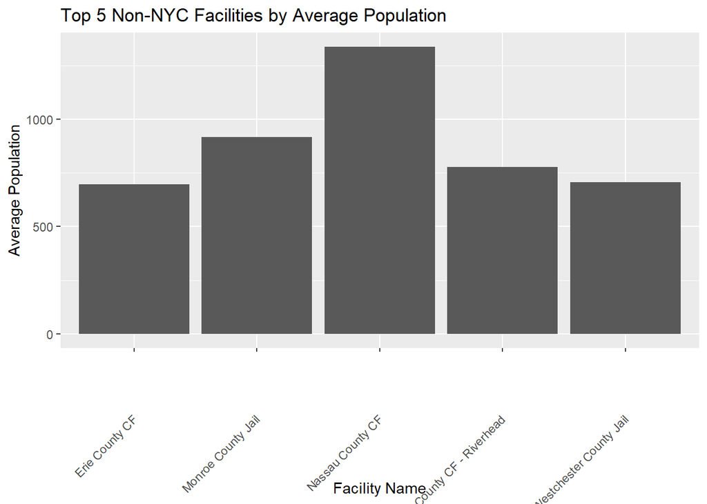

```r
# Load necessary libraries
library(ggplot2)
library(dplyr)

# Bar chart: Top 5 non-NYC facilities by average population
top_5_non_nyc_facilities <- jail_data %>%
  filter(facility_name!= "All NYC Facilities" & facility_name!= "All Non-NYC Facilities") %>%
  group_by(facility_name) %>%
  summarise(avg_population = mean(inhouse_census)) %>%
  arrange(desc(avg_population)) %>%
  head(5)

ggplot(top_5_non_nyc_facilities, aes(x = facility_name, y = avg_population)) +
  geom_bar(stat = "identity") +
  labs(title = "Top 5 Non-NYC Facilities by Average Population", x = "Facility Name", y = "Average Population") +
  theme(axis.text.x = element_text(angle = 45, vjust = 0.5, hjust = 1))
```

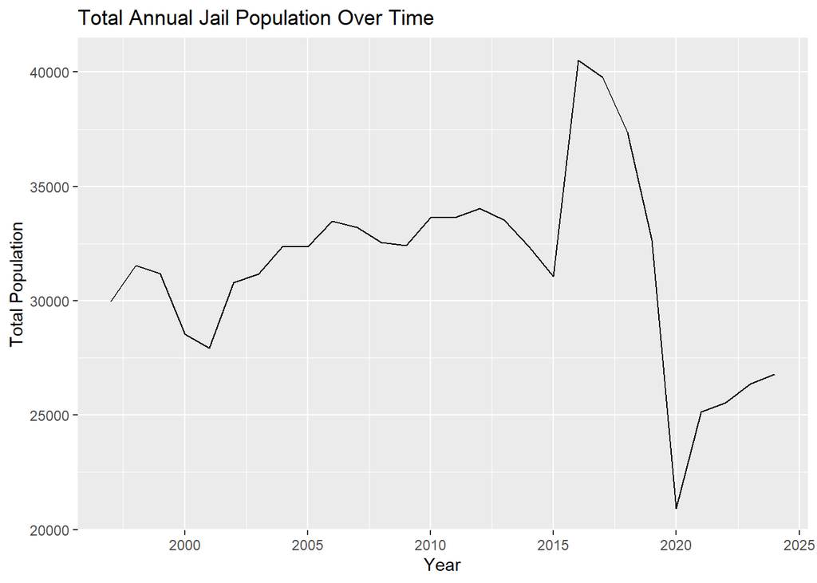

```r
# Line graph: Total annual jail population over time
ggplot(total_population, aes(x = year, y = total_population)) +
  geom_line() +
  labs(title = "Total Annual Jail Population Over Time", x = "Year", y = "Total Population")
```

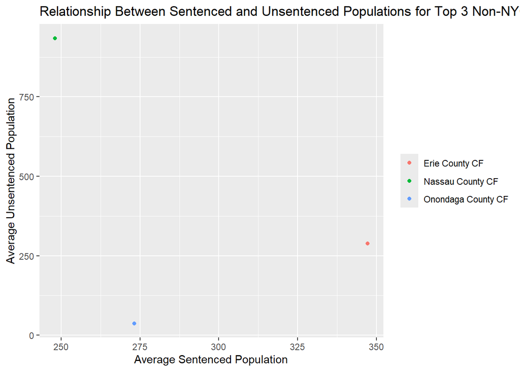

```r
# Scatter plot: Relationship between sentenced and unsentenced populations for top 3 non-NYC facilities by average population
top_3_non_nyc_facilities <- jail_data %>%
  filter(facility_name!= "All NYC Facilities" & facility_name!= "All Non-NYC Facilities") %>%
  group_by(facility_name) %>%
  summarise(avg_sentenced = mean(sentenced), avg_unsentenced = mean(other_unsentenced)) %>%
  arrange(desc(avg_sentenced)) %>%
  head(3)

ggplot(top_3_non_nyc_facilities, aes(x = avg_sentenced, y = avg_unsentenced, color = factor(facility_name))) +
  geom_point() +
  labs(title = "Relationship Between Sentenced and Unsentenced Populations for Top 3 Non-NYC Facilities", x = "Average Sentenced Population", y = "Average Unsentenced Population") +
  theme(legend.title = element_blank())
```

#### Pattern Recognition:

Supported by numerical evidence and charts, these insights highlight significant geographic differences and a notable decline in jail population over time.

## Section 4: Strategic Recommendations

#### Key Findings Summary:

These findings enable data-driven decision-making, supporting targeted expansion, adaptation to changing population trends, and optimized resource allocation. By leveraging these insights, the organization can effectively address its original business problem and drive strategic growth.